# Gov_officials

## R Markdown

read data

```r
background1 <- read.csv("background1.csv", header=T, na.strings=c("","NA"))
background2 <- read.csv("background2.csv",header=T, na.strings=c("","NA"))
backgroundNo2 <- read.csv("no_background2.csv")
area_code <- read.csv("area_code.csv")
School_code <- read.csv("SchoolCode.csv")
job_title <- read.csv("job_Title_code.csv")
```

clean data and convert var to binary 党派信息 ?= time to join the Party?

```r
background1$X <- NULL
names(background1)[4] <- '生日'


#recode
table(background1$最高学历)
```

```
##
##   不详   专科   中专   初中   博士 博士后   本科   硕士   高中
##     97    289      1     12    514     18   1115   1780     37
```

```r
background1$最高学历<- recode(background1$最高学历, 不详 = "No_inf", 专科 = "diploma", 中专 = "highS_diploma",初中 = "secondary", 博士 = "phd",博士后 = "posdoc",本科 = "undergrad",硕士 = "master",高中 = "secondary2")
#convert NA to 0
background1$最高学历[is.na(background1$最高学历)] <- "No_inf"

table(background1$现状)
```

```
##
##       不详       在职       死亡   立案查处       退休 降/辞/撤职
##         15       2395         56        273       1269         49
```

```r
background1$现状<- recode(background1$现状, 不详= "No_inf",在职 = "in_service", 死亡 = "dead",立案查处 = "investigation", 退休 = "retired" )
background1$现状 <- as.character(background1$现状)
#partical match this one due to special symbol '/' in the string
background1[grepl("降", background1$现状), "现状"] <- "dispose"

table(background1$军队) # 1= Yes
```

```
##
##   1
## 120
```

```r
background1$军队[is.na(background1$军队)] <- 'no_inf'
background1$军队<- recode(background1$军队,  "0" = "No", "1" = "Yes")

table(background1$开除党籍) #not sure what happened to NA, I'll convert them to 0
```

```
##
##  否  是
##  46 263
```

```r
background1$开除党籍 <- as.character(background1$开除党籍)
background1$开除党籍[is.na(background1$开除党籍)] <- 'no_info'
background1$开除党籍<- recode(background1$开除党籍, 否= "No",是 = "Yes")

table(background1$查处.罢黜原因)
```

```
##
##         其他 生活作风问题     责任事故     贪污腐败         违纪
##            3            3           17          254           38
```

```r
background1$查处.罢黜原因<- recode(background1$查处.罢黜原因, 其他= "other", 生活作风问题 = "scandal", 责任事故 = "negligence",贪污腐败 = "curruption", 违纪 = "breaking_rules" )

table(background1$是否复出)
```

```
##
##  否  是
## 291  30
```

```r
background1$是否复出<- recode(background1$是否复出, 否= "No", 是 = "Yes")

table(background1$是否起诉)
```

```
##
##  否  是
##  47 225
```

```r
background1$是否起诉<- recode(background1$是否起诉, 否= "No", 是 = "Yes")

table(background1$性别)
```

```
##
##   女   男
##  230 3827
```

```r
background1$性别<- recode(background1$性别, 女= "Female", 男 = "Male")

table(background2$是否全国性组织)
```

```
##
##    否    是
## 45181 17561
```

```r
background2$是否全国性组织<- recode(background2$是否全国性组织, 否= "No", 是 = "Yes")

table(background2$是否中央派出)
```

```
##
##    否    是
## 61634  1108
```

```r
background2$是否中央派出<- recode(background2$是否中央派出, 否= "No", 是 = "Yes")
```

# background1

let’s cluster the cases and see if there’s any pattern

```r
#convert factors to dummy
clean_data<-dummy.data.frame(background1,names=c('最高学历'),sep='_')
clean_data<-dummy.data.frame(clean_data,names=c('现状'),sep='_')
clean_data<-dummy.data.frame(clean_data,names=c('开除党籍'),sep='_')
clean_data<-dummy.data.frame(clean_data,names=c('查处.罢黜原因'),sep='_')
clean_data<-dummy.data.frame(clean_data,names=c('开除党籍'),sep='_')
clean_data<-dummy.data.frame(clean_data,names=c('是否复出'),sep='_')
clean_data<-dummy.data.frame(clean_data,names=c('是否全国性组织'),sep='_')
clean_data<-dummy.data.frame(clean_data,names=c('是否中央派出'),sep='_')
clean_data<-dummy.data.frame(clean_data,names=c('是否起诉'),sep='_')
clean_data<-dummy.data.frame(clean_data,names=c('性别'),sep='_')
clean_data<-dummy.data.frame(clean_data,names=c('军队'),sep='_')

#add age
clean_data$today <- as.Date("2018-09-23")
clean_data$age <- anytime(clean_data$today) - anytime(clean_data$生日)
clean_data$age <- round(as.numeric(clean_data$age/360), digits= 0)

#add how many years they have joined the party
clean_data$join_p <- anytime(clean_data$today) - anytime(clean_data$党派信息)
clean_data$join_p <- round(as.numeric(clean_data$join_p/360), digits= 0)

#age when they join the party
clean_data$join_age <- anytime(clean_data$党派信息) - anytime(clean_data$生日)
clean_data$join_age <- round(as.numeric(clean_data$join_age/3600/24/360), digits= 0)
```

# background2

calculate start - end (How long have they been in the a gov official in the party?)

```r
options(digits.secs=6)
Sys.setenv(TZ=anytime:::getTZ())
background2$time_diff <- anytime(background2$终止时间..YYYY.MM.DD..) - anytime(background2$起始时间.YYYY.MM.DD.)
background2$time_diff <- round(background2$time_diff/3600/24/360, digits= 2)
```

# add how many times they work in central？ also get the most freq province of each person

基本大类别

```r
table(background2$基本大类别)
```

```
##
##          中央企业              人大              党委            共青团
##              1001              1340             17532              2314
##              其他              军队          地方企业          基层组织
##               397              1145              3191              1903
##              学校              政协       政府_国务院          民主党派
##             11547               856             20560                 3
##       法院_检察院 行业协会_人民团体
##               250               703
```

```r
background2$基本大类别<- recode(background2$基本大类别, 中央企业= "0", 人大 = "1", 党委 = "2",共青团 = "3",  其他 = "4", 军队 = "5", 地方企业 = "6", 基层组织 = "7", 学校 = "8",政协 = "9",政府_国务院 = "10",民主党派 = "11",法院_检察院 = "12",行业协会_人民团体 = "13" )
clean_data2<-dummy.data.frame(background2,names=c('基本大类别'),sep='_')
```

地方一级关键词

```r
table(clean_data2$地方一级关键词)
```

```
##
##                 上海市                   不详                   中央
##                   2300                    119                   8284
##                   乍得                 云南省                   伊朗
##                      1                   1491                      4
##             俄罗斯联邦           内蒙古自治区                 几内亚
##                      1                   1683                      1
##                 加拿大                   加纳                 北京市
##                     14                      1                   2947
##               南斯拉夫                 卢旺达                 吉林省
##                      2                      1                   1431
##                 四川省               坦桑尼亚                   埃及
##                   3996                      2                      1
##                 天津市                 奥地利         宁夏回族自治区
##                   1684                      1                    685
##                 安徽省                 山东省                 山西省
##                   1983                   2657                   1470
##               巴基斯坦                 广东省         广西壮族自治区
##                      3                   2556                   1530
##                 意大利                   挪威           捷克斯洛伐克
##                      3                      2                      1
##                 新加坡       新疆维吾尔自治区                   日本
##                     36                   1367                     36
##           晋冀鲁豫边区             晋察冀边区                   朝鲜
##                      3                      2                      1
##                 比利时       民主德国（东德）                 江苏省
##                      3                      4                   1890
##                 江西省                 河北省                 河南省
##                   1217                   1685                   2156
##                   法国                   波兰               津巴布韦
##                      8                      2                      1
##                 浙江省                 海南省                 湖北省
##                   1438                    448                   2254
##                 湖南省               澳大利亚         澳门特别行政区
##                   1951                     14                     14
##                 爱尔兰                   瑞典                 甘肃省
##                      1                      5                   1573
##                 福建省                   美国       联邦德国（西德）
##                   1147                    221                      9
##                 肯尼亚 苏南行政区（52年撤销）                   苏联
##                      1                      1                     27
##                   英国                   荷兰                 莱索托
##                     40                      8                      1
##             西藏自治区                 贵州省                 辽宁省
##                    951                   1174                   1864
##                 重庆市                 陕西省                 青海省
##                   1908                   1360                   1024
##         香港特别行政区               黑龙江省
##                     45                   1961
```

```r
clean_data2$地方一级关键词<- recode(clean_data2$地方一级关键词, 上海市= "0", 不详 = "1", 中央 = "2",乍得 = "3",  云南省 = "4", 伊朗 = "3", 几内亚 = "3",加纳 = "3", 肯尼亚 = "3", 南斯拉夫 = "3",卢旺达 = "3",坦桑尼亚 = "3",埃及 = "3", 巴基斯坦 = "3",朝鲜 = "3",津巴布韦 = "3", 莱索托 = "3",乍得 = "3",俄罗斯联邦 = "5", 苏联 = "5",内蒙古自治区 = "6",加拿大 = "7", 奥地利 = "7",意大利 = "7",挪威 = "7",  日本 = "7",比利时 = "7",法国 = "7",波兰 = "7",澳大利亚 = "7",爱尔兰 = "7",新加坡 = "7",捷克斯洛伐克 = "7",瑞典 = "7",美国 = "7",英国 = "7",荷兰 = "7",北京市 = "8",吉林省 = "9",四川省 = "10",天津市 = "11", 宁夏回族自治区 = "12",安徽省 = "13", 山东省 = "14",山西省 = "15",广东省 = "16",广西壮族自治区 = "17",新疆维吾尔自治区 = "18",晋冀鲁豫边区 = "19",江苏省 = "20", 江西省 = "21",河北省 = "22",河南省 = "23",浙江省 = "24",海南省 = "25",湖北省 = "26",湖南省 = "27",澳门特别行政区 = "28",  香港特别行政区 = "28",甘肃省 = "29",福建省 = "30",西藏自治区 = "31", 贵州省 = "32",辽宁省 = "33",重庆市 = "34",陕西省 = "35",青海省 = "36", 黑龙江省 = "36", 晋察冀边区 = "37", 黑龙江省 = "38")
clean_data2[grepl("德国", clean_data2$地方一级关键词), "地方一级关键词"] <- "7"
clean_data2[grepl("苏南", clean_data2$地方一级关键词), "地方一级关键词"] <- "5"


clean_data2$地方一级关键词 <- factor(clean_data2$地方一级关键词)
table(clean_data2 $地方一级关键词)
```

```
##
##    0    1    2    3    4    5    6    7    8    9   10   11   12   13   14
## 2300  119 8284   20 1491   29 1683  408 2947 1431 3996 1684  685 1983 2657
##   15   16   17   18   19   37   20   21   22   23   24   25   26   27   28
## 1470 2556 1530 1367    3    2 1890 1217 1685 2156 1438  448 2254 1951   59
##   29   30   31   32   33   34   35   36
## 1573 1147  951 1174 1864 1908 1360 2985
```

```r
#convert to dummy
clean_data2<-dummy.data.frame(clean_data2,names=c('地方一级关键词'),sep='_')
```

```r
table(clean_data2$级别)
```

```
##
##     副厅     副国     副处     副部 小于副处   无级别     正厅     正国
##    10917      339     5747     7010     9911     5676    13175       71
##     正处     正部
##     8152     1744
```

```r
#convert to dummy
clean_data2$级别<- recode(clean_data2$级别, 副厅= "deputy_director", 副国 = "deputy_leader", 副处 = "deputy_dept",副部 = "vice_minister",  小于副处 = "less_dept", 无级别 = "no_rank", 正厅 = "director",正国 = "national_leader", 正处 = "dept", 正部 = "minister")
clean_data2<-dummy.data.frame(clean_data2,names=c('级别'),sep='_')
```

sum the position, place and institute for each case

```r
cols <- c(2,6:7, 9:47, 53:66, 73:82, 86)
fea2 <- clean_data2[,cols]
fea3 <- aggregate(. ~ 姓名, fea2, sum)
```

merge with background1

```r
#get background1
cols <- c(1:3, 9:17, 19:35,37:39,43:44,55:57)
fea4 <- clean_data[,cols]
#merge
fea <- merge(fea3, fea4, by = '姓名')
```

let’s cluster the data and see the patterns

```r
#convert all the var to numbers, replace NA with mean
fea$join_age <- ifelse(is.na(fea$join_age), mean(fea$join_age , na.rm=TRUE), fea$join_age)
fea$join_p <- ifelse(is.na(fea$join_p), mean(fea$join_p , na.rm=TRUE), fea$join_p)
fea$age <- ifelse(is.na(fea$age), mean(fea$age, na.rm=TRUE), fea$age)

data2 <- as.data.frame(lapply(fea[ ,2:103], as.numeric))
```

select features for clustering： ranking, time joining party, age when joining party, positions

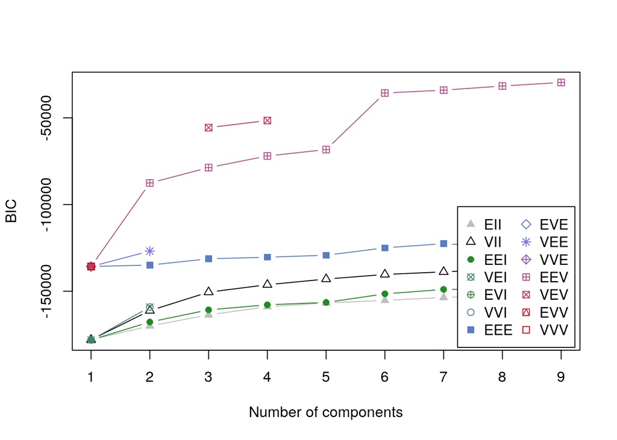

```r
# ranking, time joining party, age when joining party, positions
cols <- c(56:65,100:102,66,1:2)
data <- data2[,cols]
#cluster
#data <- data.frame(apply(data,2,rescale))
BIC <- mclustBIC(scale(data))
plot(BIC)
```

```r
summary(BIC)
```

```
## Best BIC values:
##              EEV,9      EEV,8      EEV,7
## BIC      -29578.52 -31632.667 -34002.808
## BIC diff      0.00  -2054.151  -4424.292
```

```r
mod1 <- Mclust(data, x = BIC)
s <- summary(mod1, parameters = TRUE)
```

select features for clustering： ranking, time joining party, age when joining party, positions

```r
#location
cols <- c(3:41)
data <- data2[,cols]

#PCA
prin_comp <- prcomp(data, scale. = T)
prin_comp$rotation
```

```
##                            PC1           PC2          PC3          PC4
## 地方一级关键词_0  -0.059118036  1.194310e-01 -0.057958631  0.280319241
## 地方一级关键词_1  -0.086116139  2.656133e-01 -0.430696458 -0.237214929
## 地方一级关键词_2  -0.247670243  4.547171e-01  0.285741585 -0.165004934
## 地方一级关键词_3  -0.064307907  2.062103e-01 -0.036948800  0.162194241
## 地方一级关键词_4  -0.007442776 -1.155723e-01 -0.023381499 -0.034891585
## 地方一级关键词_5  -0.133273680  3.235852e-01 -0.103653602 -0.375114236
## 地方一级关键词_6  -0.040242154 -7.437809e-02  0.078237610 -0.075545305
## 地方一级关键词_7  -0.062021675  3.838429e-01  0.177825262  0.476328195
## 地方一级关键词_8  -0.146397528  2.392486e-01  0.324947400 -0.130166050
## 地方一级关键词_9  -0.041413807 -3.984418e-02 -0.018061137 -0.015957577
## 地方一级关键词_10  0.651546707  2.104101e-01  0.048148108 -0.062259679
## 地方一级关键词_11 -0.049386348 -5.197568e-02 -0.066385729  0.021978821
## 地方一级关键词_12 -0.022259160 -8.873352e-02 -0.008896890 -0.084820787
## 地方一级关键词_13 -0.043790296 -6.204240e-02 -0.034538086  0.067660152
## 地方一级关键词_14 -0.036937060 -7.314179e-02 -0.023463265  0.031955241
## 地方一级关键词_15 -0.028853983 -7.097305e-02  0.029593364 -0.099145381
## 地方一级关键词_16 -0.040827353  4.727831e-02 -0.377663283  0.178504361
## 地方一级关键词_17 -0.039226830  4.940103e-06  0.101264386  0.098571890
## 地方一级关键词_18 -0.040809677 -1.103755e-02  0.052881805 -0.049241416
## 地方一级关键词_19 -0.053383742  1.199721e-01  0.050127035 -0.231433615
## 地方一级关键词_37 -0.024474039  3.804002e-02  0.059028936 -0.060943983
## 地方一级关键词_20 -0.043265136  4.572895e-02 -0.029294043  0.390616442
## 地方一级关键词_21 -0.026533594 -7.350145e-02 -0.087799001  0.046048622
## 地方一级关键词_22 -0.051962136  1.475803e-02  0.161596318  0.095545530
## 地方一级关键词_23 -0.027874605 -1.191731e-01 -0.075555847 -0.087445818
## 地方一级关键词_24 -0.022457753 -2.723653e-02 -0.155375647  0.013603028
## 地方一级关键词_25 -0.064765891  1.444822e-01 -0.295375838  0.081249455
## 地方一级关键词_26 -0.046885284 -3.076334e-02  0.030477771  0.138636402
## 地方一级关键词_27 -0.030343627 -8.365277e-02 -0.049708092  0.051733130
## 地方一级关键词_28 -0.067643697  2.985412e-01 -0.423029395 -0.032233502
## 地方一级关键词_29 -0.026003016 -7.125233e-02  0.048648274 -0.088334509
## 地方一级关键词_30 -0.024534018 -6.360719e-02 -0.039282622  0.049410550
## 地方一级关键词_31 -0.029976060 -6.442143e-03  0.134761053 -0.159038317
## 地方一级关键词_32 -0.027668191 -1.141103e-02  0.040039385  0.004480675
## 地方一级关键词_33 -0.030464730 -1.073127e-01  0.012956527 -0.124551097
## 地方一级关键词_34  0.635722809  2.109910e-01  0.013679915 -0.039766977
## 地方一级关键词_35 -0.048462040  1.626315e-02  0.006845801 -0.104040536
## 地方一级关键词_36 -0.052706599 -1.224571e-01  0.043861470 -0.142822560
## 地方一级关键词_NA -0.075587529  1.663300e-01  0.204806506  0.080978950
```

[output cut: 345 more lines]

```
## 地方一级关键词_23  0.0367329025 -0.0177943249  0.210638687
## 地方一级关键词_24 -0.0267514830 -0.0079435441  0.157103159
## 地方一级关键词_25 -0.1469787025  0.0100521989  0.047027582
## 地方一级关键词_26 -0.0457896691 -0.0134813808  0.199200276
## 地方一级关键词_27 -0.0210046727 -0.0172884784  0.195921091
## 地方一级关键词_28 -0.2707155759 -0.0032021858  0.008130634
## 地方一级关键词_29 -0.0279502660 -0.0203821553  0.188012231
## 地方一级关键词_30 -0.0405085748 -0.0075829141  0.152562287
## 地方一级关键词_31 -0.1802215885 -0.0295665456  0.125964910
## 地方一级关键词_32 -0.0730529096 -0.0003813486  0.140856537
## 地方一级关键词_33 -0.0190345992 -0.0161314208  0.195112886
## 地方一级关键词_34  0.0022204183 -0.7281315632  0.126130072
## 地方一级关键词_35 -0.0541285112 -0.0125492805  0.158097347
## 地方一级关键词_36 -0.0930942698 -0.0187584973  0.232403825
## 地方一级关键词_NA -0.1154346419  0.0018505109  0.015293559
```

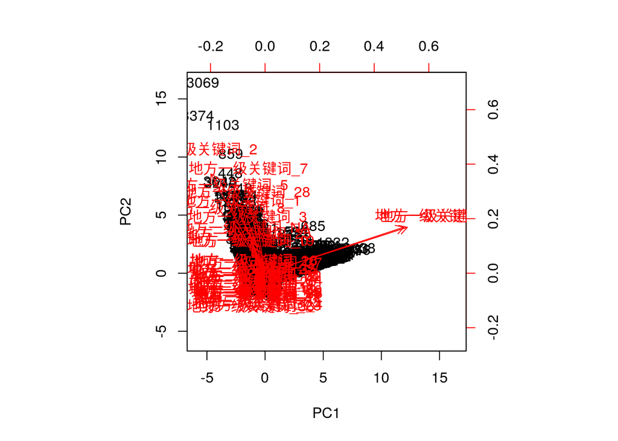

```r
biplot(prin_comp, scale = 0)
```

frequency of changing positions. does freq related to edu? ranking?

```r
#should add frequency of changing position  freq/time_diff   how often do they change a position
freq_change_pos <- data.frame(table(background2$姓名))
freq_all <- merge(freq_change_pos,fea, by.x = "Var1", by.y = "姓名")
#how many years dp they get to change a postion?
freq_all$freq_change_pos_nor <- freq_all$time_diff/freq_all$Freq

#frequency of workin in central
central <- background2 %>%
  group_by(姓名) %>%
  filter(., 地方一级关键词 == "中央")

central_freq <- data.frame(table(central$姓名))
colnames(central_freq) <- c('Var1','central_freq')
freq_all <- merge(central_freq,freq_all, by = "Var1")
```

Let’s do the cluster again adding the frequency of working in central and frequency of changing positions

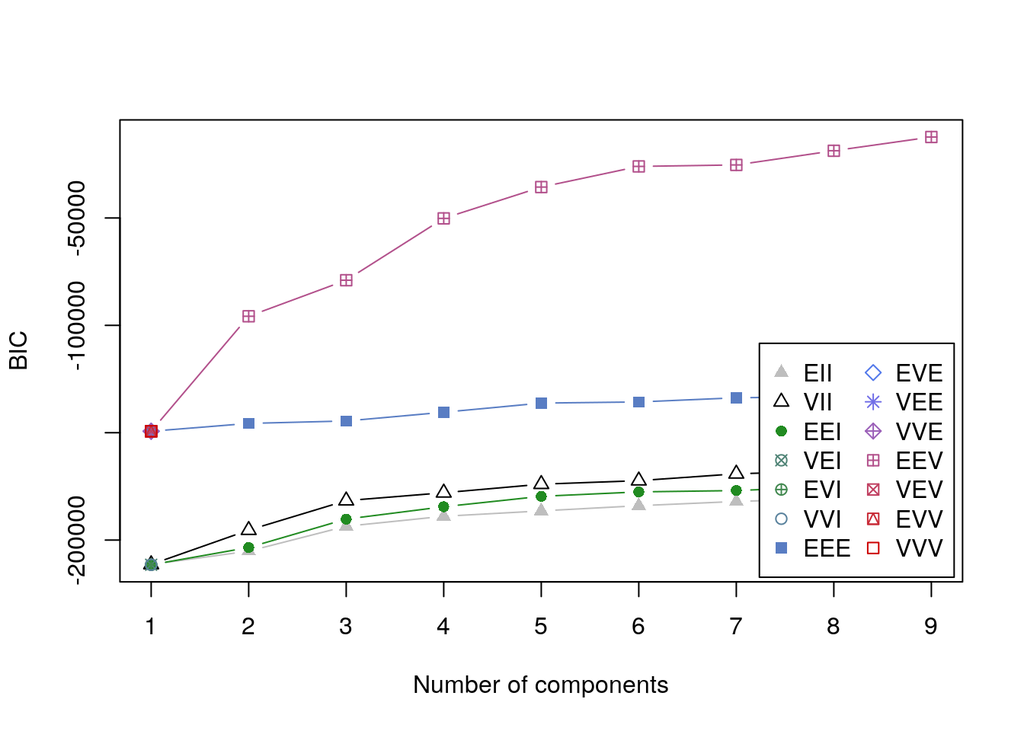

```r
# ranking, time joining party, age when joining party, positions
cols <- c(2:5, 59:69, 103:106 )
data <- freq_all[,cols]
#cluster
#data <- data.frame(apply(data,2,rescale))
BIC <- mclustBIC(scale(data))
plot(BIC)
```

```r
summary(BIC)
```

```
## Best BIC values:
##              EEV,9      EEV,8     EEV,7
## BIC      -12275.67 -18678.634 -25288.84
## BIC diff      0.00  -6402.968 -13013.17
```

```r
mod1 <- Mclust(data, x = BIC)
s <- summary(mod1, parameters = TRUE)
#shows means of each group
s[11]
```

```
## $mean
##                             [,1]       [,2]       [,3]       [,4]
## central_freq          5.59945311  0.7209855  2.3996561  7.3787019
## Freq                 15.78323141 18.2541961 16.2127855 19.6413423
## 是否全国性组织       18.95178735 22.2051219 22.1243602 28.2508731
## 是否中央派出         15.12744305 18.5076891 15.6492086 19.2295094
## 级别_deputy_director  1.19186939  3.8233337  2.3825199  1.5958852
## 级别_deputy_leader    0.02245072  0.0000000  0.0000000  2.3301929
## 级别_deputy_dept      0.56287244  2.0402390  1.3443972  0.9175657
## 级别_vice_minister    3.16714544  0.5414899  1.4547647  3.8535274
## 级别_less_dept        1.30792799  3.3884168  2.5655053  2.3860171
## 级别_no_rank          1.37981147  1.7160560  2.0063074  1.6802212
## 级别_director         1.97435820  3.7769679  3.2630026  2.0910043
## 级别_national_leader  0.00000000  0.0000000  0.0000000  0.0000000
## 级别_dept             0.80618741  2.9463781  2.0471134  1.3761838
## 级别_minister         2.53419382  0.0000000  0.5442441  2.5401920
## time_diff            55.66829715 49.4081059 47.9513674 69.9293651
## age                  76.03109135 61.5316844 65.4548001 76.8299850
## join_p               49.40325532 37.2472591 42.3084303 52.1942063
## join_age             25.79485808 23.4354027 23.6710499 24.0211532
## freq_change_pos_nor   3.75122456  2.7894153  3.0422315  3.6880230
##                              [,5]      [,6]       [,7]      [,8]     [,9]
## central_freq          0.251269220  3.128700  3.3632033  5.029697  7.81250
## Freq                  7.262767322 16.886713 12.7045244 19.500539 17.71875
## 是否全国性组织        4.449584977 22.160785 12.0040669 26.856665 26.65625
## 是否中央派出          4.142303795 16.931719  9.2221428 20.059747 18.53125
## 级别_deputy_director  0.671796688  2.742356  1.5092612  2.091941  1.18750
## 级别_deputy_leader    0.000000000  0.000000  0.0000000  0.000000  2.56250
## 级别_deputy_dept      0.006022062  1.397685  0.9110788  1.298097  0.65625
## 级别_vice_minister    0.660489878  3.057529  1.6845316  4.571546  2.87500
## 级别_less_dept        0.034258855  2.443491  1.0679180  2.670432  1.90625
## 级别_no_rank          0.168063925  1.657027  0.6597117  1.690943  1.34375
## 级别_director         2.348729358  3.700127  2.2612573  3.061070  1.43750
## 级别_national_leader  0.000000000  0.000000  0.0000000  0.000000  2.21875
## 级别_dept             0.187072163  1.874583  0.8356020  1.743848  1.21875
## 级别_minister         0.000000000  0.000000  0.2662028  2.370423  2.12500
## time_diff            16.414238679 55.611243 39.1354496 65.031818 92.93094
## age                  66.045410913 65.319055 68.2584238 72.586317 80.14274
## join_p               40.941545844 40.541481 41.8935426 48.394580 58.46875
## join_age             23.612115959 23.920096 24.4059326 23.438348 22.23940
## freq_change_pos_nor   2.919595426  3.493640  3.4953248  3.390073  5.99992
```

Let’s do a regression

```r
#recode ranking here we recode no_ranking = 1, ranked = 0
recode_r <- background2[, c(2,22)]
recode_r$级别<- recode(recode_r$级别, 副厅= 9, 副国 = 2, 副处 = 6,副部 = 4,  小于副处 = 7, 无级别 = 10, 正厅 = 8,正国 = 1, 正处 = 5, 正部 = 4)
#clean_data2<-dummy.data.frame(clean_data2,names=c('级别'),sep='_')
#select the highest ranking of each person
highest_rank <- aggregate(级别 ~ 姓名, data = recode_r, min)
#merge with features
all <- merge(highest_rank,freq_all, by.x = '姓名', by.y = 'Var1')

#regress the highest ranking
cols <- c(2:6, 70, 104:107 )
reg_fea <- all[cols]
l <- lm(formula = 级别 ~ ., data = reg_fea)
summary(l)
```

```
##
## Call:
## lm(formula = 级别 ~ ., data = reg_fea)
##
## Residuals:
##     Min      1Q  Median      3Q     Max
## -3.3850 -0.4986 -0.0551  0.4183  4.0881
##
## Coefficients:
##                      Estimate Std. Error t value Pr(>|t|)
## (Intercept)          7.926182   0.160934  49.251  < 2e-16 ***
## central_freq        -0.064700   0.006661  -9.713  < 2e-16 ***
## Freq                -0.078231   0.008140  -9.610  < 2e-16 ***
## 是否全国性组织       0.009975   0.005907   1.689 0.091372 .
## 是否中央派出         0.029310   0.008694   3.371 0.000756 ***
## time_diff           -0.022120   0.001635 -13.528  < 2e-16 ***
## age                 -0.008692   0.005398  -1.610 0.107448
## join_p              -0.020044   0.005644  -3.551 0.000388 ***
## join_age            -0.026568   0.006349  -4.184 2.92e-05 ***
## freq_change_pos_nor  0.172431   0.019765   8.724  < 2e-16 ***
## ---
## Signif. codes:  0 '***' 0.001 '**' 0.01 '*' 0.05 '.' 0.1 ' ' 1
##
## Residual standard error: 0.8661 on 3907 degrees of freedom
## Multiple R-squared:  0.4459, Adjusted R-squared:  0.4446
## F-statistic: 349.3 on 9 and 3907 DF,  p-value: < 2.2e-16
```

let’s try svm to predit those work in the province or above level remove age, because regression shows it’s not predictive

```r
highest_rank$级别<- recode(highest_rank$级别,  "1" = 1, "2" = 1, "3" = 1,  "7" = 0, "10" = 0, "8" = 0, "9" = 0, "4" = 1, "5" = 0, "6" = 0)
#select the highest ranking of each person
table(highest_rank$级别)
```

```
##
##    0    1
## 1941 1982
```

```r
#merge with features
all2 <- merge(highest_rank,freq_all, by.x = '姓名', by.y = 'Var1')


#svm predict highest ranking
cols <- c(2:6, 70, 104:107 )
svm_fea <- all2[cols]


set.seed(123)
smp_size <- floor(0.70 * nrow(svm_fea))
train_ind <- sample(seq_len(nrow(svm_fea)), size = smp_size)
train <- svm_fea[train_ind, ]
test <- svm_fea[-train_ind, ]

#Fit a model. The function syntax is very similar to lm function
model_svm <- svm(as.factor(级别) ~ . , train)
#Use the predictions on the data
pred <- predict(model_svm, test)

y <- as.factor(test$级别)
predictions <- pred

precision <- posPredValue(predictions, y, positive="1")
recall <- sensitivity(predictions, y, positive="1")

#78% accurate
(2 * precision  * recall) / (precision + recall)
```

```
## [1] 0.7714777
```

```r
table(y,predictions)
```

```
##    predictions
## y     0   1
##   0 461 113
##   1 153 449
```